# Trabajo Marco: soluciones

## Problema 1

### Enunciado

```r
set.seed(05072000)

n_states <- 11
n_alternativas <- 5

tabla1 <- crea.tablaX(rexp(n_states*n_alternativas),
                    numalternativas = n_alternativas,
                    numestados = n_states)
knitr::kable(tabla1)
```

|  | e1 | e2 | e3 | e4 | e5 | e6 | e7 | e8 | e9 | e10 | e11 |
| --- | --- | --- | --- | --- | --- | --- | --- | --- | --- | --- | --- |
| d1 | 1.9227956 | 1.0930421 | 0.5439560 | 0.3565044 | 1.8626272 | 0.8910948 | 0.0630385 | 0.9718176 | 1.4737807 | 0.7044855 | 3.1732797 |
| d2 | 1.5812022 | 5.7571905 | 0.0920660 | 0.3544414 | 1.8318082 | 0.1310732 | 0.7041387 | 0.4886055 | 0.6262955 | 3.0404385 | 1.4588033 |
| d3 | 0.3834669 | 0.3744587 | 0.0571306 | 0.6968438 | 0.6242158 | 1.3167732 | 0.6256910 | 1.1553158 | 0.6514291 | 1.4039621 | 1.1438264 |
| d4 | 0.5095021 | 2.2848813 | 0.1072336 | 0.9498671 | 1.6185042 | 4.6941616 | 0.6971087 | 0.0822742 | 0.1551562 | 1.8982052 | 0.3072510 |
| d5 | 0.4218837 | 0.6186527 | 0.7807989 | 0.2393121 | 0.0566404 | 1.9735234 | 3.8549705 | 1.6076501 | 0.2206629 | 0.0222299 | 0.0836233 |

### Solucion

```r
computing_crit_results <- function(tablaX, favorable, alfa){
  crit_results <- list()
  crit_results[["Wald"]] <- criterio.Wald(tablaX = tablaX, favorable = favorable)
  crit_results[["Optimista"]] <- criterio.Optimista(tablaX = tablaX, favorable = favorable)
  crit_results[["Hurwicz"]] <- criterio.Hurwicz(tablaX = tablaX, favorable = favorable,  alfa = alfa)
  crit_results[["Laplace"]] <- criterio.Laplace(tablaX = tablaX, favorable = favorable)
  crit_results[["Savage"]] <- criterio.Savage(tablaX = tablaX,favorable = favorable)
  crit_results[["PuntoIdeal"]] <- criterio.PuntoIdeal(tablaX = tablaX, favorable = favorable)
  return(crit_results)
}
```

#### Beneficios

```r
ES_FAVORABLE <- TRUE
results <- computing_crit_results(tablaX = tabla1,
                                  favorable = ES_FAVORABLE,
                                  alfa = 0.5)
#results
table_sol <- list()
for(name in names(results)){
  table_sol[["Criterio"]] <- c(table_sol[["Criterio"]], results[[name]]$criterio)
  table_sol[["Alternativa Optima"]] <- c(table_sol[["Alternativa Optima"]], results[[name]]$AlternativaOptima)
}
names(table_sol) <- c("Criterio", "Alternativa Optima")
table_sol <- as.data.frame(table_sol)

knitr::kable(table_sol)
```

| Criterio | Alternativa.Optima |
| --- | --- |
| Wald | 2 |
| Optimista | 2 |
| Hurwicz | 2 |
| Laplace | 2 |
| Savage | 4 |
| Punto Ideal | 2 |

#### Costes

```r
ES_FAVORABLE <- FALSE
results <- computing_crit_results(tablaX = tabla1,
                                  favorable = ES_FAVORABLE,
                                  alfa = 0.5)
#results
table_sol <- list()
for(name in names(results)){
  table_sol[["Criterio"]] <- c(table_sol[["Criterio"]], results[[name]]$criterio)
  table_sol[["Alternativa Optima"]] <- c(table_sol[["Alternativa Optima"]], results[[name]]$AlternativaOptima)
}
names(table_sol) <- c("Criterio", "Alternativa Optima")
table_sol <- as.data.frame(table_sol)

knitr::kable(table_sol)
```

| Criterio | Alternativa.Optima |
| --- | --- |
| Wald | 3 |
| Optimista | 5 |
| Hurwicz | 3 |
| Laplace | 3 |
| Savage | 3 |
| Punto Ideal | 3 |

## Problema 2

### Enunciado

Un agricultor de un remoto pueblo al pie del volcan Vesubio tiene que decidir qué hortalizas plantar en su campo. Cada hortaliza lleva asociado un precio de venta (€/kg), un número de unidades que pueden plantarse en el campo y un coeficiente que representa la probabilidad de supervivencia a un clima específico.

```r
vegetables <- data.frame(
  name = c("Patata", "Tomate", "Berenjena", "Pimientos", "Calabacines", "Cebolla"),
  price_per_kg = c(1.39, 2.40, 1.84, 3.12, 1.88, 1.46),
  quantity = c(300, 240, 300, 200, 300, 300),
  survival_coeff_clima1 = c(0.7, 0.3, 0.4, 0.2, 0.3, 0.8),
  survival_coeff_clima2 = c(0.8, 0.5, 0.6, 0.7, 0.5, 0.8),
  survival_coeff_clima3 = c(0.7, 0.8, 0.5, 0.6, 0.7, 0.8)
)

knitr::kable(vegetables)
```

| name | price_per_kg | quantity | survival_coeff_clima1 | survival_coeff_clima2 | survival_coeff_clima3 |
| --- | --- | --- | --- | --- | --- |
| Patata | 1.39 | 300 | 0.7 | 0.8 | 0.7 |
| Tomate | 2.40 | 240 | 0.3 | 0.5 | 0.8 |
| Berenjena | 1.84 | 300 | 0.4 | 0.6 | 0.5 |
| Pimientos | 3.12 | 200 | 0.2 | 0.7 | 0.6 |
| Calabacines | 1.88 | 300 | 0.3 | 0.5 | 0.7 |
| Cebolla | 1.46 | 300 | 0.8 | 0.8 | 0.8 |

### Solucion

Construcion de la tabla decision

```r
temp <- NULL
table_per_lines <- c()

for(i in 1:6){
  temp <- unlist(vegetables[i,4:6]*vegetables[i,2]*vegetables[i,3])
  names(temp) <- NULL
  table_per_lines <- c(table_per_lines, temp)
}
```

Resolucion

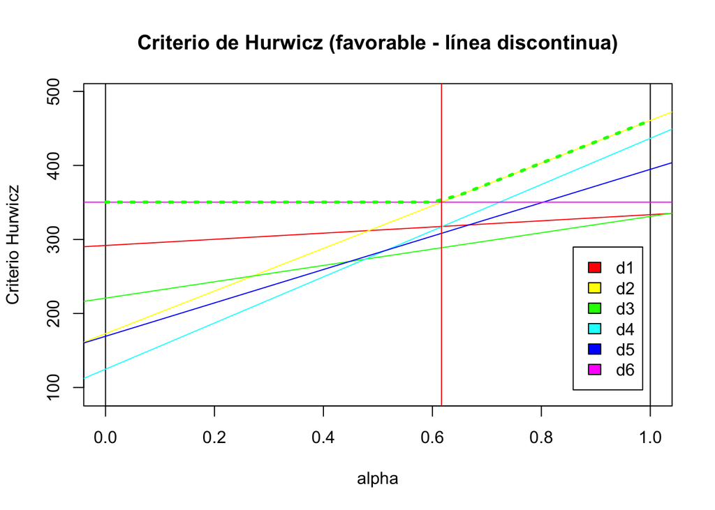

```
## $AltOptimas
## [1] 6 2
##
## $PuntosDeCorte
## [1] 0.617
##
## $IntervalosAlfa
##      Intervalo       Alternativa
## [1,] "( 0 , 0.617 )" "6"
## [2,] "( 0.617 , 1 )" "2"
```

```r
table <- crea.tablaX(table_per_lines,
                     numalternativas = 6,
                     numestados = 3)

dibuja.criterio.Hurwicz_Intervalos(tablaX = table)
```

```r
criterio.Todos(table, alfa = 0.5)
```

```
##                    e1    e2    e3  Wald Optimista Hurwicz Savage Laplace
## d1              291.9 333.6 291.9 291.9     333.6   312.8  168.9   305.8
## d2              172.8 288.0 460.8 172.8     460.8   316.8  177.6   307.2
## d3              220.8 331.2 276.0 220.8     331.2   276.0  184.8   276.0
## d4              124.8 436.8 374.4 124.8     436.8   280.8  225.6   312.0
## d5              169.2 282.0 394.8 169.2     394.8   282.0  181.2   282.0
## d6              350.4 350.4 350.4 350.4     350.4   350.4  110.4   350.4
## iAlt.Opt (fav.)    --    --    --    d6        d2      d6     d6      d6
##                 Punto Ideal
## d1                    206.4
## d2                    231.7
## d3                    249.2
## d4                    241.6
## d5                    247.3
## d6                    140.2
## iAlt.Opt (fav.)          d6
```

La mejor opción para el agricultor es cultivar cebollas de acuerdo con todos los criterios de decision considerados, excepto por el criterio optimista y el criterio de Hurwicz con grado de optimismo mayor que 0.617. Si el agricultor es bastante optimista que las condiciones climaticas van a ser buenas entonces eligirà de cultivar tomate.